# 4.2: Stock Collapse

### Unit 4: Fisheries

#### Lesson 2: Using joins for a relational database

### Fisheries Data

In this unit we will be using the RAM Legacy Database:

https://www.ramlegacy.org/

The RAM Legacy Stock Assessment Database is a compilation of stock assessment results for commercially exploited marine populations from around the world. It is inspired by Dr. Ransom A. Myers’ original stock-recruitment database, which is no longer being updated.

Go to the RAM Legacy website and click through to download the latest version of the RAM data from Zenodo. The data (rather inefficiently, if you ask me) is delivered in multiple formats simultaneously, including Microsoft Excel files and RData files. Since we are using R, I’m going to load the RData file using the `load()` function.

Note: Usually when I receive Excel files, I convert them to `.csv` files and read them in with `read.csv()`, but there is also an R package to load Excel files directly into R called `readxl`. Please be careful using Excel on large datasets, as Microsoft limits the number of rows that can exist in a spreadsheet. RAM Legacy handles this by breaking large datasets into multiple sheets (such as timeseries.1, timeseries.2 and timeseries.3). Mishandling this can cause the unintentional loss of valuable data, see this BBC article about lost Covid-19 test results: https://www.bbc.com/news/technology-54423988

```r
load('data/RAMLDB v4.66/R Data/DBdata[asmt][v4.66].RData')
```

The RAM data is structured as a large relational database which contains many different tables of different sizes and shapes, and the tables are related to each other through a series of different ids. The database has over 50 tables and some tables have over 1 million rows. This data (and many other super valuable massive datasets just like this) is difficult to work with and maneuver at first. I’m going to show you what metadata files I used to get familiar with the database so that I could start this fisheries analysis.

From the `Database Quick Guide` document, we find out that the `biometrics` table describes all parameter types available in the `bioparams` table, and the `tsmetrics` table describes all time series types available in the `timeseries` table. A simple version of the most commonly used fisheries metrics by stock and by year is available in `timeseries_values_views`. Then if we look in the `Database Structure` document, there is a map that generally shows how the major types of tables are connected:

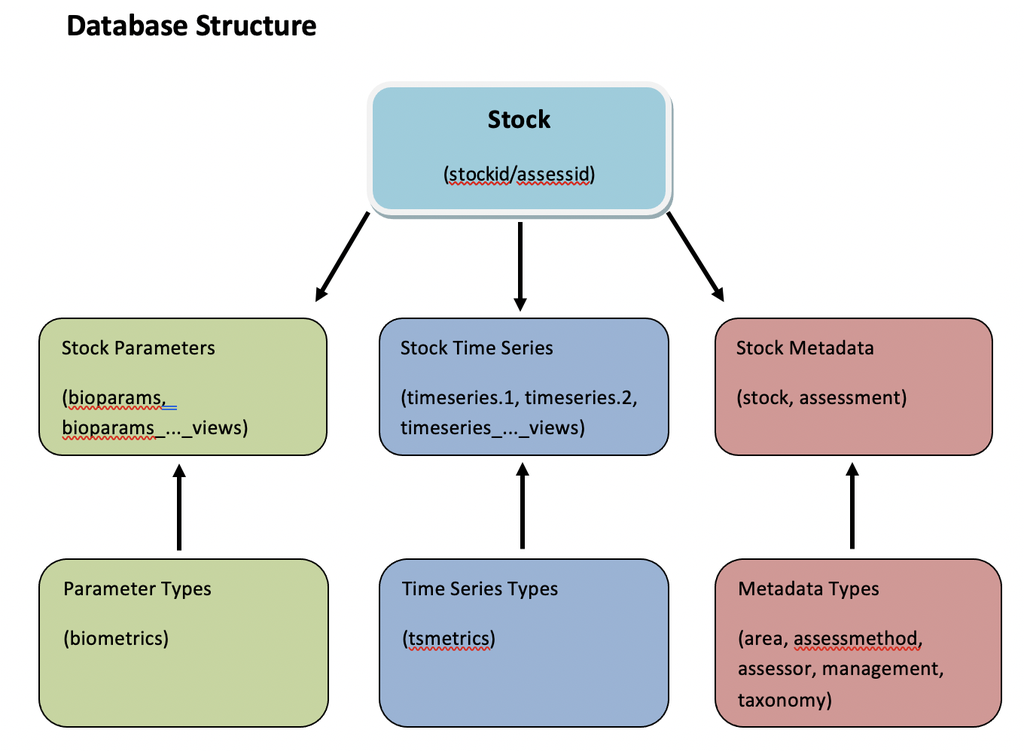

Looking deeper in the `Database Structure` document, there is a table called “Table Linkages” that lists which IDs can be used to link the different tables. For example, both the `timeseries_values_views` table and `stock` table have a common ID called `stockid`.

The other good metadata file provided is called `Database Table Fields`. This is a spreadsheet that provides explanations for the variable names that represent the broad range of fishery metrics presented in this dataset. Now that we have glanced through the metadata, we can start a fisheries analysis.

Most of the data in the RAM database is in the `timeseries` table, but the metadata for this table is stored in `tsmetrics`. Using the table in the Database Structure file, we see that these two tables can be joined by matching the `tsid` column in `timeseries` with the `tsunique` column in the `tsmetrics` table. We do this with a `left_join()` and check the dimensions of our tables before and after the join to make sure we didn’t add or subtract any rows from the `timeseries` table. Now we have a better understanding of the meaning of each row in our new table:

```r
library(tidyverse)
```

```r
glimpse(tsmetrics)
## Rows: 457
## Columns: 6
## $ tscategory   <chr> "OTHER TIME SERIES DATA", "OTHER TIME SERIES DATA", "TOTA…
## $ tsshort      <chr> "AQ", "ASP", "BdivBmgtpref", "BdivBmgttouse", "BdivBmsypr…
## $ tslong       <chr> "Aquaculture", "Annual surplus production", "General biom…
## $ tsunitsshort <chr> "MT", "MT", "dimensionless", "dimensionless", "dimensionl…
## $ tsunitslong  <chr> "metric tons", "Metric tons", "dimensionless", "dimension…
## $ tsunique     <chr> "AQ-MT", "ASP-MT", "BdivBmgtpref-dimensionless", "BdivBmg…
glimpse(timeseries)
## Rows: 1,643,974
## Columns: 6
## $ assessid  <chr> "ABARES-BGRDRSE-1960-2011-CHING", "ABARES-BGRDRSE-1960-2011-…
## $ stockid   <chr> "BGRDRSE", "BGRDRSE", "BGRDRSE", "BGRDRSE", "BGRDRSE", "BGRD…
## $ stocklong <chr> "Blue grenadier Southeast Australia", "Blue grenadier Southe…
## $ tsid      <chr> "CdivMEANC-ratio", "CdivMEANC-ratio", "CdivMEANC-ratio", "Cd…
## $ tsyear    <dbl> 1960, 1961, 1962, 1963, 1964, 1965, 1966, 1967, 1968, 1969, …
## $ tsvalue   <dbl> NA, NA, NA, NA, NA, NA, NA, NA, NA, NA, NA, NA, NA, NA, NA, …
timeseries_tsmetrics = timeseries %>% left_join(tsmetrics, by=c("tsid" = "tsunique"))
dim(timeseries)
## [1] 1643974       6
dim(timeseries_tsmetrics)
## [1] 1643974      11
glimpse(timeseries_tsmetrics)
## Rows: 1,643,974
## Columns: 11
## $ assessid     <chr> "ABARES-BGRDRSE-1960-2011-CHING", "ABARES-BGRDRSE-1960-20…
## $ stockid      <chr> "BGRDRSE", "BGRDRSE", "BGRDRSE", "BGRDRSE", "BGRDRSE", "B…
## $ stocklong    <chr> "Blue grenadier Southeast Australia", "Blue grenadier Sou…
## $ tsid         <chr> "CdivMEANC-ratio", "CdivMEANC-ratio", "CdivMEANC-ratio", …
## $ tsyear       <dbl> 1960, 1961, 1962, 1963, 1964, 1965, 1966, 1967, 1968, 196…
## $ tsvalue      <dbl> NA, NA, NA, NA, NA, NA, NA, NA, NA, NA, NA, NA, NA, NA, N…
## $ tscategory   <chr> "CATCH or LANDINGS", "CATCH or LANDINGS", "CATCH or LANDI…
## $ tsshort      <chr> "CdivMEANC", "CdivMEANC", "CdivMEANC", "CdivMEANC", "Cdiv…
## $ tslong       <chr> "Catch divided by mean catch", "Catch divided by mean cat…
## $ tsunitsshort <chr> "ratio", "ratio", "ratio", "ratio", "ratio", "ratio", "ra…
## $ tsunitslong  <chr> "ratio", "ratio", "ratio", "ratio", "ratio", "ratio", "ra…
```

This is just to get you warmed up to relational databases. Now let’s use some other tables for some cool analyses.

### Annual total catch by stock

We are going to look in the `timeseries_values_views` dataset for annual total catch for each fish stock. The `TCbest` column is the best available annual total catch data (in metric tons). The actual data is all in `timeseries`, but the `timeseries` table may have multiple stock assessments for a given year, which complicates things. We’ll stick with the simplified `timeseries_values_views` table. If we join it with the `stock` dataset using `stockid` then we can add more information about each stock, such as `scientificname` and `region`. If we join these with the `taxonomy` table using `tsn` then we can add more info about the species classification and the fishery type.

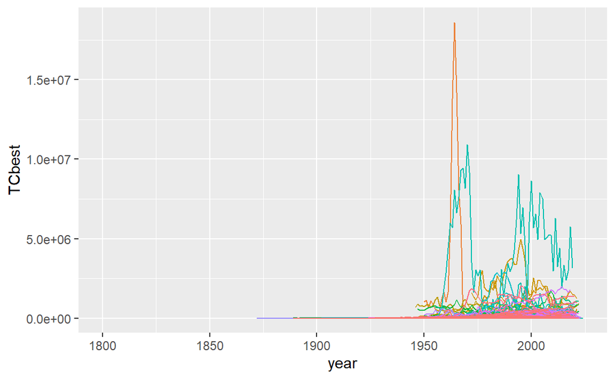

```r
# Check units for TCbest by searching for this value type in the tsmetrics table
tsmetrics %>% filter(tsshort == "TCbest")
##          tscategory tsshort                                          tslong
## 1 CATCH or LANDINGS  TCbest General total Catch (TC then TL, MT units only)
##   tsunitsshort tsunitslong  tsunique
## 1           MT Metric tons TCbest-MT
# unique(timeseries_units_views$TCbest) # All TCbest units are in metric tons

# Ensure that there is one tsn for each scientific name in the taxonomy table
length(unique(taxonomy$scientificname))
## [1] 404
length(unique(taxonomy$tsn)) # Taxonomic Serial Number
## [1] 404

# Join timeseries_values_views, stock and taxonomy tables
fish = timeseries_values_views %>%
  left_join(stock, by=c("stockid", "stocklong")) %>%
  left_join(taxonomy, by = c("tsn", "scientificname")) %>% # could join metadata table instead
  select(stockid, stocklong, year, TCbest, tsn, scientificname, commonname, region, FisheryType, taxGroup)

dim(fish) # Make sure number of rows is the same as timeseries_values_views
## [1] 63176    10
dim(timeseries_values_views)
## [1] 63176    38

# Fishery with highest annual catch
glimpse( fish %>% arrange(desc(TCbest)) ) # what had the highest catch?
## Rows: 63,176
## Columns: 10
## $ stockid        <chr> "ATBTUNAWATL", "ATBTUNAWATL", "ATBTUNAWATL", "PANCHPERU…
## $ stocklong      <chr> "Atlantic bluefin tuna Western Atlantic", "Atlantic blu…
## $ year           <dbl> 1964, 1965, 1963, 1970, 1968, 1967, 1971, 1994, 2000, 1…
## $ TCbest         <dbl> 18600000, 14200000, 13800000, 10929653, 9450926, 931468…
## $ tsn            <chr> " 172421", " 172421", " 172421", " 551340", " 551340", …
## $ scientificname <chr> "Thunnus thynnus", "Thunnus thynnus", "Thunnus thynnus"…
## $ commonname     <chr> "Atlantic bluefin tuna", "Atlantic bluefin tuna", "Atla…
## $ region         <chr> "Atlantic Ocean", "Atlantic Ocean", "Atlantic Ocean", "…
## $ FisheryType    <chr> "Tuna and Marlin", "Tuna and Marlin", "Tuna and Marlin"…
## $ taxGroup       <chr> "tuna-billfish", "tuna-billfish", "tuna-billfish", "for…

# This plot has LOTS of data - make sure you remove the legend !!
ggplot() +
  geom_line(aes(x=year, y=TCbest, color=stockid), data=fish) +
  theme(legend.position = "none")
## Warning: Removed 18690 rows containing missing values or values outside the scale range
## (`geom_line()`).
```

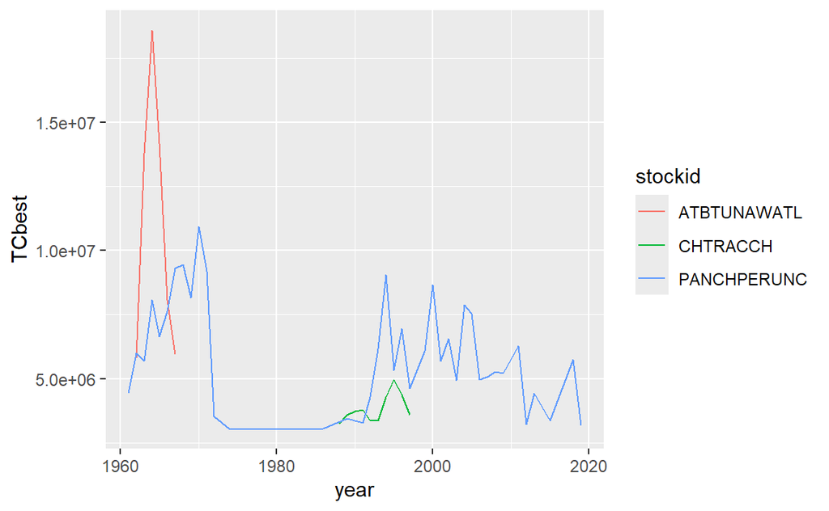

```r
ggsave('figures/total_catch_all_stocks.png', device="png", height=4, width=7, units="in")
## Warning: Removed 18690 rows containing missing values or values outside the scale range
## (`geom_line()`).

# Take a closer peek at a few of the highest catches in history:
fish %>%
  filter(TCbest > 3e6) %>%
  select(stockid, stocklong, year, TCbest)
##        stockid                                       stocklong year   TCbest
## 1  ATBTUNAWATL          Atlantic bluefin tuna Western Atlantic 1962  5800000
## 2  ATBTUNAWATL          Atlantic bluefin tuna Western Atlantic 1963 13800000
## 3  ATBTUNAWATL          Atlantic bluefin tuna Western Atlantic 1964 18600000
## 4  ATBTUNAWATL          Atlantic bluefin tuna Western Atlantic 1965 14200000
## 5  ATBTUNAWATL          Atlantic bluefin tuna Western Atlantic 1966  8080000
## 6  ATBTUNAWATL          Atlantic bluefin tuna Western Atlantic 1967  5940000
## 7     CHTRACCH  Chilean jack mackerel Chilean EEZ and offshore 1988  3246000
## 8     CHTRACCH  Chilean jack mackerel Chilean EEZ and offshore 1989  3582000
## 9     CHTRACCH  Chilean jack mackerel Chilean EEZ and offshore 1990  3715000
## 10    CHTRACCH  Chilean jack mackerel Chilean EEZ and offshore 1991  3778000
## 11    CHTRACCH  Chilean jack mackerel Chilean EEZ and offshore 1992  3362000
## 12    CHTRACCH  Chilean jack mackerel Chilean EEZ and offshore 1993  3371000
## 13    CHTRACCH  Chilean jack mackerel Chilean EEZ and offshore 1994  4276000
## 14    CHTRACCH  Chilean jack mackerel Chilean EEZ and offshore 1995  4956000
## 15    CHTRACCH  Chilean jack mackerel Chilean EEZ and offshore 1996  4380000
## 16    CHTRACCH  Chilean jack mackerel Chilean EEZ and offshore 1997  3598000
## 17 PANCHPERUNC Peruvian anchoveta North-Central Peruvian coast 1961  4415607
## 18 PANCHPERUNC Peruvian anchoveta North-Central Peruvian coast 1962  5993538
## 19 PANCHPERUNC Peruvian anchoveta North-Central Peruvian coast 1963  5682287
## 20 PANCHPERUNC Peruvian anchoveta North-Central Peruvian coast 1964  8078297
## 21 PANCHPERUNC Peruvian anchoveta North-Central Peruvian coast 1965  6636311
## 22 PANCHPERUNC Peruvian anchoveta North-Central Peruvian coast 1966  7623551
## 23 PANCHPERUNC Peruvian anchoveta North-Central Peruvian coast 1967  9314686
## 24 PANCHPERUNC Peruvian anchoveta North-Central Peruvian coast 1968  9450926
## 25 PANCHPERUNC Peruvian anchoveta North-Central Peruvian coast 1969  8157802
## 26 PANCHPERUNC Peruvian anchoveta North-Central Peruvian coast 1970 10929653
## 27 PANCHPERUNC Peruvian anchoveta North-Central Peruvian coast 1971  9184394
## 28 PANCHPERUNC Peruvian anchoveta North-Central Peruvian coast 1972  3521915
## 29 PANCHPERUNC Peruvian anchoveta North-Central Peruvian coast 1974  3037604
## 30 PANCHPERUNC Peruvian anchoveta North-Central Peruvian coast 1976  3032768
## 31 PANCHPERUNC Peruvian anchoveta North-Central Peruvian coast 1986  3060445
## 32 PANCHPERUNC Peruvian anchoveta North-Central Peruvian coast 1989  3451982
## 33 PANCHPERUNC Peruvian anchoveta North-Central Peruvian coast 1991  3267117
## 34 PANCHPERUNC Peruvian anchoveta North-Central Peruvian coast 1992  4276687
## 35 PANCHPERUNC Peruvian anchoveta North-Central Peruvian coast 1993  6179606
## 36 PANCHPERUNC Peruvian anchoveta North-Central Peruvian coast 1994  9047114
## 37 PANCHPERUNC Peruvian anchoveta North-Central Peruvian coast 1995  5326850
## 38 PANCHPERUNC Peruvian anchoveta North-Central Peruvian coast 1996  6952926
## 39 PANCHPERUNC Peruvian anchoveta North-Central Peruvian coast 1997  4614383
## 40 PANCHPERUNC Peruvian anchoveta North-Central Peruvian coast 1999  6070812
## 41 PANCHPERUNC Peruvian anchoveta North-Central Peruvian coast 2000  8653641
## 42 PANCHPERUNC Peruvian anchoveta North-Central Peruvian coast 2001  5688432
## 43 PANCHPERUNC Peruvian anchoveta North-Central Peruvian coast 2002  6561174
## 44 PANCHPERUNC Peruvian anchoveta North-Central Peruvian coast 2003  4936876
## 45 PANCHPERUNC Peruvian anchoveta North-Central Peruvian coast 2004  7886233
## 46 PANCHPERUNC Peruvian anchoveta North-Central Peruvian coast 2005  7542689
## 47 PANCHPERUNC Peruvian anchoveta North-Central Peruvian coast 2006  4963697
## 48 PANCHPERUNC Peruvian anchoveta North-Central Peruvian coast 2007  5084926
## 49 PANCHPERUNC Peruvian anchoveta North-Central Peruvian coast 2008  5268884
## 50 PANCHPERUNC Peruvian anchoveta North-Central Peruvian coast 2009  5214696
## 51 PANCHPERUNC Peruvian anchoveta North-Central Peruvian coast 2011  6288495
## 52 PANCHPERUNC Peruvian anchoveta North-Central Peruvian coast 2012  3233893
## 53 PANCHPERUNC Peruvian anchoveta North-Central Peruvian coast 2013  4415191
## 54 PANCHPERUNC Peruvian anchoveta North-Central Peruvian coast 2015  3353161
## 55 PANCHPERUNC Peruvian anchoveta North-Central Peruvian coast 2018  5758514
## 56 PANCHPERUNC Peruvian anchoveta North-Central Peruvian coast 2019  3151481

ggplot() +
  geom_line(aes(x=year, y=TCbest, color=stockid), data=fish %>% filter(TCbest > 3e6))
```

### Cod collapse

Now that we have created a nice neat data set of all of the best available time series of total catch for fisheries all around the world, we can take a more detailed look at specific stocks. Let’s examine the infamous collapse of the Canadian cod stock.

Newfoundland and Labrador’s historic cod fisheries attracted local and international fishing fleets for almost five centuries before the Canadian government shut the industry down indefinitely in July 1992. By then, once-plentiful fish stocks had dwindled to near extinction and officials feared they would disappear entirely if the fisheries remained open. The moratorium put about 30,000 people in the province out of work and ended a way of life that had endured for generations in many port communities. It also made evident the vulnerability of marine resources to overexploitation and that existing regulatory regimes were insufficient to protect cod stocks.

Let’s isolate the cod stock assessments in East Coast Canada and add them together. Then we can plot a time series of the total Canadian East Coast cod stock and try to see what the collapse looked like.

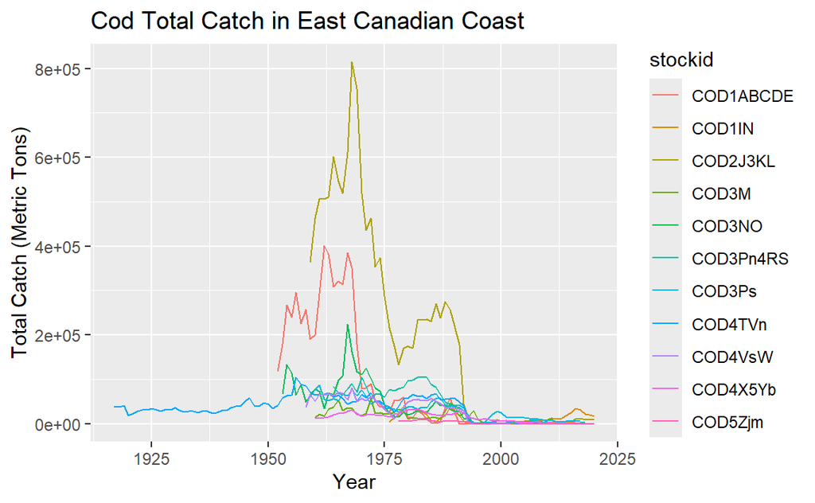

```r
# What regions have Atlantic cod stock assessments?
fish %>%
  filter(scientificname == "Gadus morhua") %>%
  distinct(region)
##              region
## 1 Canada East Coast
## 2     Europe non EU
## 3    European Union
## 4     US East Coast

# Examine Cod catch in each Canada East Coast stock
cod_can = fish %>%
  filter(scientificname == "Gadus morhua",
         region == "Canada East Coast",
         !is.na(TCbest))

# Plot Canada East Coast cod catch time series for each stock
ggplot(aes(x=year, y=TCbest, color=stockid), data=cod_can) +
  geom_line() +
  labs(x= "Year", y= "Total Catch (Metric Tons)",
       title = "Cod Total Catch in East Canadian Coast")
```

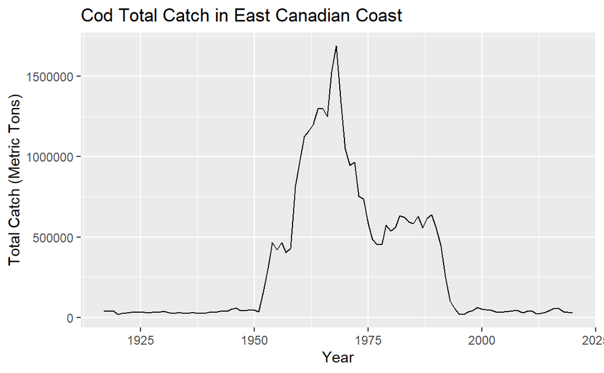

```r
# Sum best Total Catch estimates for Cod across all Canada East Coast stock assessments
cod_can_total = cod_can %>%
  group_by(year) %>%
  summarise(total_catch = sum(TCbest))

# Plot Canada East Coast cod total catch time series
ggplot(aes(x=year, y=total_catch), data=cod_can_total) +
  geom_line() +
  labs(x= "Year", y= "Total Catch (Metric Tons)",
       title = "Cod Total Catch in East Canadian Coast")
```

A paper by Boris Worm et al. (2006; see the readings directory) defines a fishery stock collapse as a decline in total catch to less than 10% of the maximum historical total catch. Did the Eastern Canadian cod stock “collapse” according to this definition? We’ll use the `cummax()` function which returns the maximum value in all rows of a data frame previous to a particular row, to find the historical maximum (i.e. the max catch observed prior to each year within the analysis). We can identify the year the collapse occurred and add that to our time series plot.

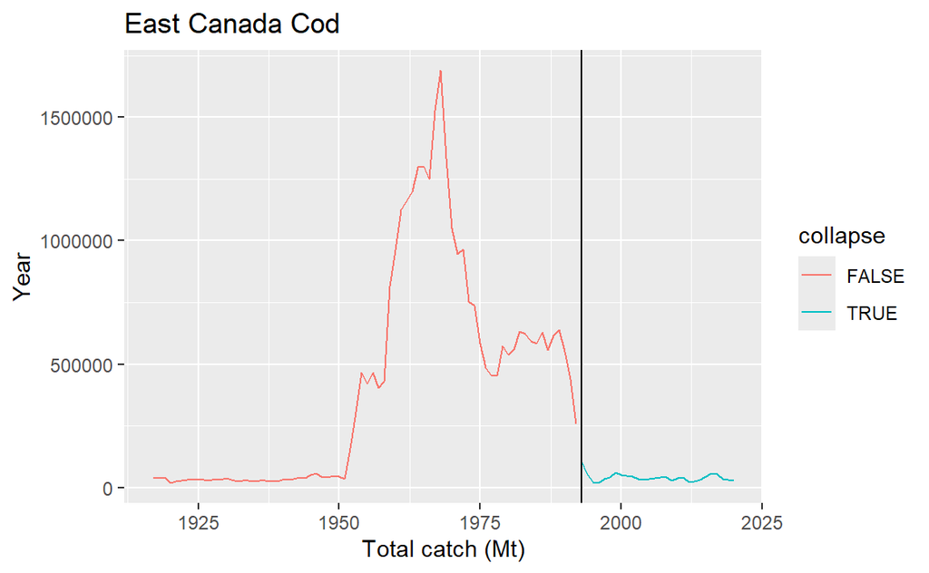

```r
# Test how the cum functions work
dat = c(1,3,6,2,3,9,-1) # some random data for testing
dat_max = cummax(dat) # cummax() returns the cumulative maximum value
dat_sum = cumsum(dat) # cumsum() returns the cumulative sum value
test_cum = data.frame(dat, dat_max, dat_sum)
test_cum
##   dat dat_max dat_sum
## 1   1       1       1
## 2   3       3       4
## 3   6       6      10
## 4   2       6      12
## 5   3       6      15
## 6   9       9      24
## 7  -1       9      23

# Find the historical max total catch for each year in the time series
# Define collapse as a total catch <= 10% of the historical max catch
# cummax() in row i provides the max value in rows 0 - i
cod_collapse = cod_can_total %>%
  mutate(historical_max_catch = cummax(total_catch),
         collapse = total_catch <= 0.1*historical_max_catch)

# What year did the collapse happen?
cod_collapse_year = cod_collapse %>%
  filter(collapse==TRUE) %>%
  summarize(year=min(year)) %>%
  pull(year)

# Plot the catch time series and the collapse year
ggplot() +
  geom_line(aes(y=total_catch, x=year, color=collapse), data=cod_collapse) +
  geom_vline(xintercept = cod_collapse_year) + # Draws vertical line
  #scale_x_continuous(breaks=c(seq(0,2015,10))) + # Add more breaks on x axis
  xlab("Total catch (Mt)") + ylab("Year") + ggtitle("East Canada Cod")
```

### Examine fishery collapse across ALL stocks

Now that we have explored what a stock collapse looks like with cod in Eastern Canadian waters, let’s look at the whole RAM dataset and count the number of stocks that have collapsed. How do stock collapse events change through time? How do they change by geographic region?

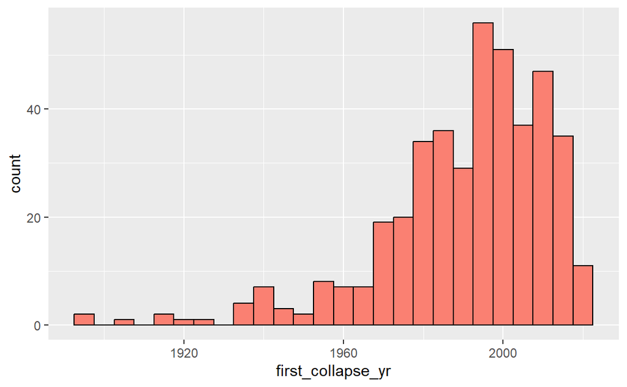

```r
# Find all stocks that have collapsed
collapse = fish %>%
  filter(!is.na(TCbest)) %>%  # Remove NAs (which can't be ignored with cummax())
  group_by(stockid) %>%
  mutate(historical_max_catch = cummax(TCbest),
         current_collapse = TCbest < 0.10 * historical_max_catch,
         collapsed_yet = cumsum(current_collapse) > 0) %>%
  ungroup()

# Find the year each stock collapsed for the first time
collapse_yr = collapse %>%
  group_by(stockid, stocklong, region) %>% # really just groups by stockid, but retains stocklong and region
  filter(collapsed_yet == TRUE) %>%
  summarize(first_collapse_yr = min(year)) %>%
  ungroup()
## `summarise()` has regrouped the output.
## ℹ Summaries were computed grouped by stockid, stocklong, and region.
## ℹ Output is grouped by stockid and stocklong.
## ℹ Use `summarise(.groups = "drop_last")` to silence this message.
## ℹ Use `summarise(.by = c(stockid, stocklong, region))` for per-operation
##   grouping (`?dplyr::dplyr_by`) instead.

# Plot a histogram of first collapse year
ggplot(data = collapse_yr, aes(x=first_collapse_yr)) +
  geom_histogram(color="black", fill="salmon", binwidth=5) # bin into 5-yr-intervals
```

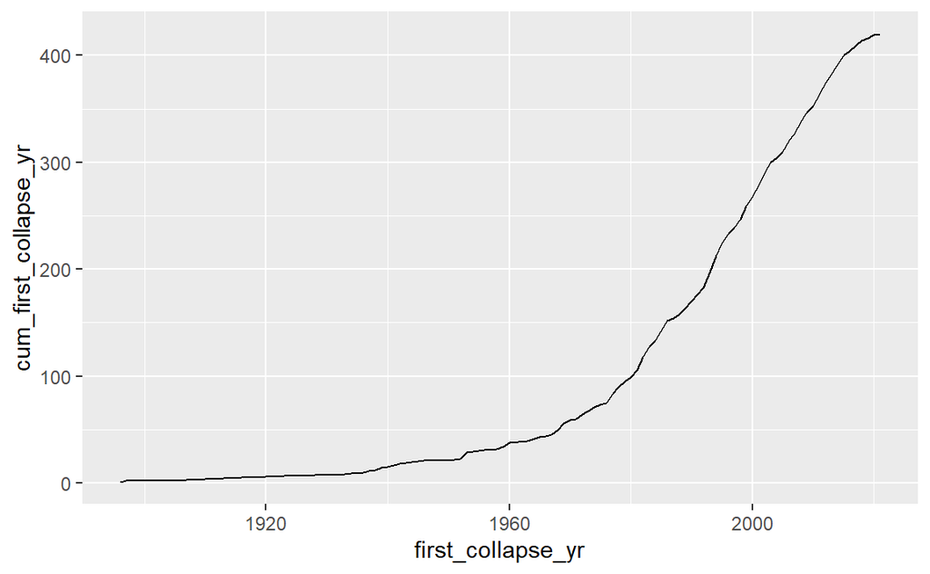

```r
# Create a time series of # of stocks ever collapsed / total stocks
n_stocks = length(unique(collapse$stockid))
collapse_ts = collapse_yr %>%
  count(first_collapse_yr) %>% # Count number of stocks that collapsed each yr
  mutate(cum_first_collapse_yr = cumsum(n),
         ratio_collapsed_yet = cum_first_collapse_yr/n_stocks)

ggplot(data = collapse_ts, aes(x=first_collapse_yr, y=cum_first_collapse_yr)) +
  geom_line()
```

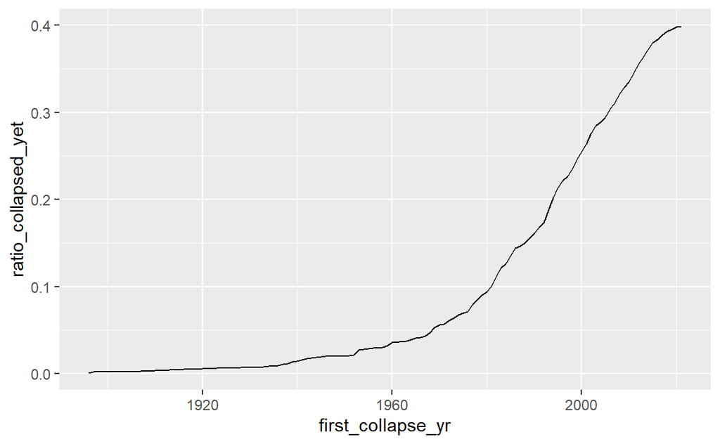

```r
ggplot(data = collapse_ts, aes(x=first_collapse_yr, y=ratio_collapsed_yet)) +
  geom_line()
```

### Exercise 2.1

Create the same time series that shows the # of stocks that have collapsed (historically) divided by the total number of stocks that are tracked in the dataset. However, show this plot separately for EACH region. You may need to create a new data frame that counts the number of stocks tracked in each region, then join that new data frame to the collapse_ts data frame to calculate your ratios.